# Alyssa Bockman and Thalia Koutsougeras

Milestone 1

**Final Project** Disease Prevalence Across the States

Data from: https://think.cs.vt.edu/corgis/csv/health/

GitHub: https://github.com/abfender/abfender.github.io

## Project Plan

**Project Description and Goals:** This dataset will allow us to examine the prevalence of various diseases across all 50 states over the last century. We plan to research factors such a vaccination rates and to try and understand the peaks and valleys in the dataset. We also want to examine what regions and states have been most and least affected and compare it with factors like weather patterns and population density.

**Collaboration Plan:** Our collaboration plan is to meet at least once a week over zoom on Wednesday nights. We met in person twice to work on Milestone 1. We already have each other’s phone numbers, and we have set up our private Github repository where we uploaded our preliminary notebook files.

Milestone 2 requirements (5 Points) Professionalism: You have used both code comments and markdown cells to professionally and clearly document your work including having a clear and clean notebook; linking to resources and documents; and doing so with code that is reasonable and efficient. Your notebook is correct and contains the required links. In addition, you have written code that is interpretable – it contains comments where needed to understand, variable names are reasonable, and code that is reasonable and efficient. You have followed directions to turn in the file, clearly labeling everything. You have cited all sources and how you used them in the written portion of your answers.

(5 Points) Extraction, Transform, and Load (ETL): You are now using more than one dataset and they are both loaded correctly using web scraping other techniques. The data is discussed in terms of what it is and how it could be used to answer the question of study. Where the data comes from and how it is collected is clearly documented with links and other relevant details. The data is imported and tidy according to the principles discussed in class. Dtypes are set properly and displayed within the notebook, NaN’s and other techniques are used following best practices discussed in class.

(5 Points) Exploratory Data Analysis (EDA): At least 5 graphs and/or summary statistics/tables including cross-tabulations, groups, measures of central tendency, and/or any of the other EDA techniques discussed showing that you have started to investigate your data and have an understanding of what is in your dataset. Each of these pieces of analysis should have a corresponding markdown cell that clearly explains what is being shown and why. (5 Points) Model Questions: You have identified at least two plausible models that you could build using your data and the graphs in your EDA section support continuing the investigation. You have clearly identified independent and dependent variables and appropriate test/prediction methodology for each question.

## Data Selection and Filtering

Data from: https://think.cs.vt.edu/corgis/csv/health/

```python
from google.colab import drive
drive.mount('/content/drive')
%cd /content/drive/My Drive/cmps3160
```

```
/content/drive/My Drive/cmps3160
```

```python
%cd /content/drive/My Drive/cmps3160/finalProject
```

```
/content/drive/My Drive/cmps3160/finalProject
```

### Preliminary Data Analysis - National Incidence and Case Numbers

```python
import pandas as pd
import matplotlib.pyplot as plt
#import pandas and matplotlib for graphing

df = pd.read_csv("../finalProject/health.csv", sep=",")
#read dataset into variable df

#check what values are missing
df[df.isnull().any(axis=1)]
```

|  | disease | increase | loc | number | population | year |
| --- | --- | --- | --- | --- | --- | --- |

Lucky for us, no data is missing and we can proceed onto analysis!

```python
#Data types analysis
```

```python
measles = df[df['disease'] == "MEASLES"]
measles['increase'].min()
```

```
0.0
```

```python
#in order to visualize the case prevelance across the entire country, we will drop the
#location and increase columns and then create seperate dataframes for each disease
#df = df.drop(columns=['loc', 'increase'])
measles = df[df['disease'] == "MEASLES"]
polio = df[df['disease'] == "POLIO"]
smallpox = df[df['disease'] == "SMALLPOX"]
pertussis = df[df['disease'] == "PERTUSSIS"]
hepa = df[df['disease'] == "HEPATITIS A"]
rubella = df[df['disease'] == "RUBELLA"]
mumps = df[df['disease'] == "MUMPS"]
```

Now that we have datasets that hold only the specific disease information for each illness, we can begin to perform some basic analysis.

We will extract data to get numbers in the country instead of by state and perform further analysis to calculate the incidence for each disease each year.

In public health there are 2 main ways to measure how disease affects a population: incidence and prevalence.

Incidence refers to the number of people that develop/are diagnosed within a time period divided by the total sample size, while prevalence refers to the number of people being actively affected by the disease (whether they were diagnosed within the time period or not) divided by the total smaple size.

Because this data set provides us with the number of new cases per year and nothing about the amount of time people were sick, we will be focusing on calculating the incidence for each disease throughout the entire country.

This will provide 1 helpful dataset for each disease that will allow us to graph both the case numbers in the country as well as the proportion of people affected over the years.

#### Measles

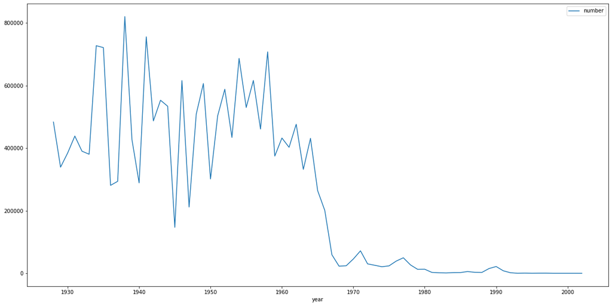

```python
#Measles

#grab the case numbers country wide for each year
measles_country = measles.groupby(by='year')['number'].sum()

#grab the population size country side for each year
measles_population = measles.groupby(by='year')['population'].sum()

#transform the number and population series in to dataframes for future operations
measles_country = measles_country.to_frame()
measles_population = measles_population.to_frame()

#join the number and population dataframes to allow us to create a new incidence column
measles_incidence = measles_population.join(other=measles_country, on='year')

#create a new column called incidence that shows the proportion of the population affected each year
measles_incidence["incidence"] = measles_incidence["number"]/measles_incidence["population"]

#change the index to regular numbers rather than the year
measles_incidence.reset_index(inplace =True)

measles_incidence.head()

measles_incidence.plot.line(x = 'year', y = 'number', figsize=(20,10))
```

#### Polio

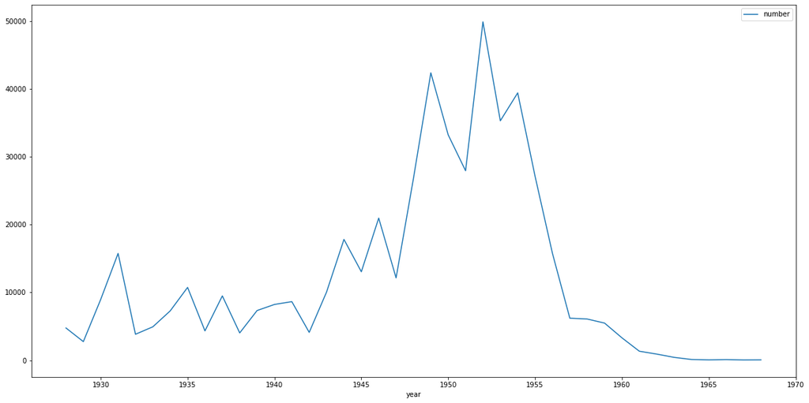

```python
#Polio

#grab the case numbers country wide for each year
polio_country = polio.groupby(by='year')['number'].sum()

#grab the population size country side for each year
polio_population = polio.groupby(by='year')['population'].sum()

#transform the number and population series in to dataframes for future operations
polio_country = polio_country.to_frame()
polio_population = polio_population.to_frame()

#join the number and population dataframes to allow us to create a new incidence column
polio_incidence = polio_population.join(other=polio_country, on='year')

#create a new column called incidence that shows the proportion of the population affected each year
polio_incidence["incidence"] = polio_incidence["number"]/polio_incidence["population"]

#change the index to regular numbers rather than the year
polio_incidence.reset_index(inplace = True)

polio_incidence.head()

polio_incidence.plot.line(x = 'year', y = 'number', figsize=(20,10))
```

#### Smallpox

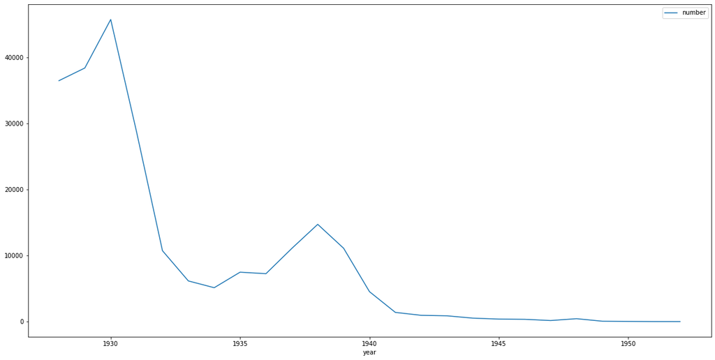

```python
#Smallpox

#grab the case numbers country wide for each year
smallpox_country = smallpox.groupby(by='year')['number'].sum()

#grab the population size country side for each year
smallpox_population = smallpox.groupby(by='year')['population'].sum()

#transform the number and population series in to dataframes for future operations
smallpox_country = smallpox_country.to_frame()
smallpox_population = smallpox_population.to_frame()

#join the number and population dataframes to allow us to create a new incidence column
smallpox_incidence = smallpox_population.join(other=smallpox_country, on='year')

#create a new column called incidence that shows the proportion of the population affected each year
smallpox_incidence["incidence"] = smallpox_incidence["number"]/smallpox_incidence["population"]

#change the index to regular numbers rather than the year
smallpox_incidence.reset_index(inplace = True)

smallpox_incidence.head()

smallpox_incidence.plot.line(x = 'year', y = 'number', figsize=(20,10))
```

#### Pertussis

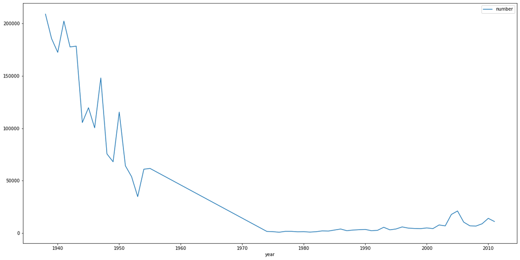

```python
#Pertussis

#grab the case numbers country wide for each year
pertussis_country = pertussis.groupby(by='year')['number'].sum()

#grab the population size country side for each year
pertussis_population = pertussis.groupby(by='year')['population'].sum()

#transform the number and population series in to dataframes for future operations
pertussis_country = pertussis_country.to_frame()
pertussis_population = pertussis_population.to_frame()

#join the number and population dataframes to allow us to create a new incidence column
pertussis_incidence = pertussis_population.join(other=pertussis_country, on='year')

#create a new column called incidence that shows the proportion of the population affected each year
pertussis_incidence["incidence"] = pertussis_incidence["number"]/pertussis_incidence["population"]

#change the index to regular numbers rather than the year
pertussis_incidence.reset_index(inplace = True)

pertussis_incidence.head()

pertussis_incidence.plot.line(x = 'year', y = 'number', figsize=(20,10))
```

#### Hepatitis A

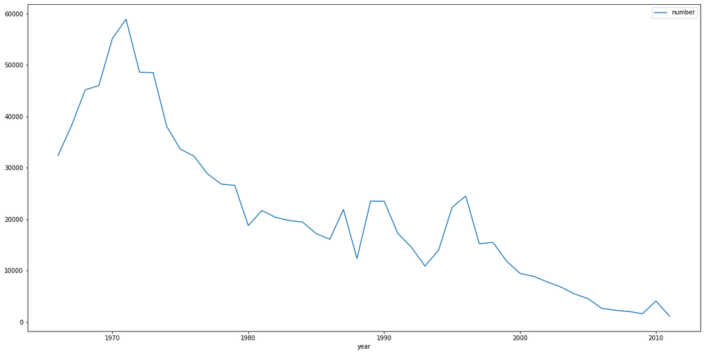

```python
#Hepatitis A

#grab the case numbers country wide for each year
hepa_country = hepa.groupby(by='year')['number'].sum()

#grab the population size country side for each year
hepa_population = hepa.groupby(by='year')['population'].sum()

#transform the number and population series in to dataframes for future operations
hepa_country = hepa_country.to_frame()
hepa_population = hepa_population.to_frame()

#join the number and population dataframes to allow us to create a new incidence column
hepa_incidence = hepa_population.join(other=hepa_country, on='year')

#create a new column called incidence that shows the proportion of the population affected each year
hepa_incidence["incidence"] = hepa_incidence["number"]/hepa_incidence["population"]

#change the index to regular numbers rather than the year
hepa_incidence.reset_index(inplace = True)

hepa_incidence.head()

hepa_incidence.plot.line(x = 'year', y = 'number', figsize=(20,10))
```

#### Rubella

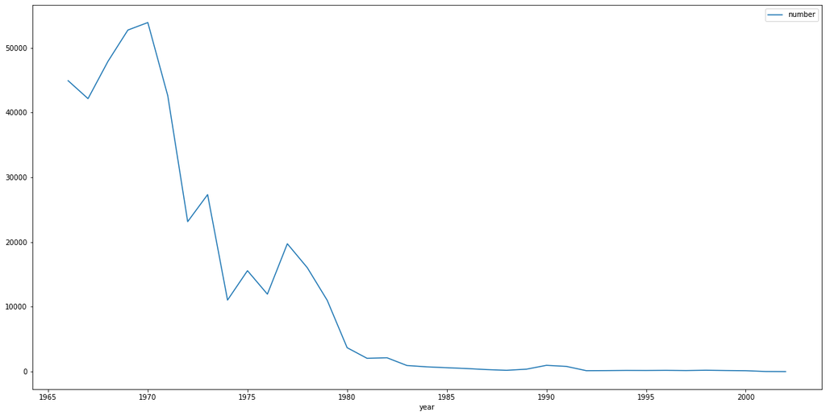

```python
#Rubella

#grab the case numbers country wide for each year
rubella_country = rubella.groupby(by='year')['number'].sum()

#grab the population size country side for each year
rubella_population = rubella.groupby(by='year')['population'].sum()

#transform the number and population series in to dataframes for future operations
rubella_country = rubella_country.to_frame()
rubella_population = rubella_population.to_frame()

#join the number and population dataframes to allow us to create a new incidence column
rubella_incidence = rubella_population.join(other=rubella_country, on='year')

#create a new column called incidence that shows the proportion of the population affected each year
rubella_incidence["incidence"] = rubella_incidence["number"]/rubella_incidence["population"]

#change the index to regular numbers rather than the year
rubella_incidence.reset_index(inplace = True)

rubella_incidence.head()

rubella_incidence.plot.line(x = 'year', y = 'number', figsize=(20,10))
```

#### Mumps

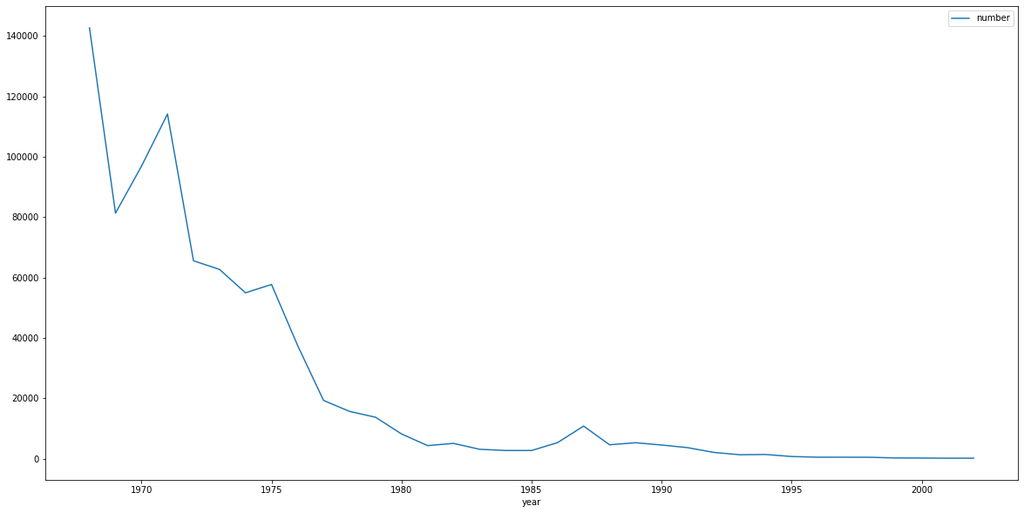

```python
#Mumps

#grab the case numbers country wide for each year
mumps_country = mumps.groupby(by='year')['number'].sum()

#grab the population size country side for each year
mumps_population = mumps.groupby(by='year')['population'].sum()

#transform the number and population series in to dataframes for future operations
mumps_country = mumps_country.to_frame()
mumps_population = mumps_population.to_frame()

#join the number and population dataframes to allow us to create a new incidence column
mumps_incidence = mumps_population.join(other=mumps_country, on='year')

#create a new column called incidence that shows the proportion of the population affected each year
mumps_incidence["incidence"] = mumps_incidence["number"]/mumps_incidence["population"]

#change the index to regular numbers rather than the year
mumps_incidence.reset_index(inplace = True)

mumps_incidence.head()

mumps_incidence.plot.line(x = 'year', y = 'number', figsize=(20,10))
```

#### National Case Numbers and National Incidence

```
(1925.0, 2015.0)
```

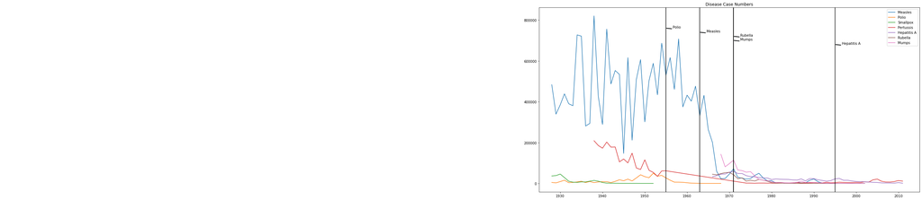

```python
vaccine_data = [("Measles", 1963), ("Polio", 1955), ("Smallpox", 1798), ("Pertussis", 1915), ("Hepatitis A", 1995), ("Rubella", 1971), ("Mumps", 1971)]
vaccine_df = pd.DataFrame(vaccine_data, columns=['Disease', 'Year'])
vaccine_df = vaccine_df.sort_values('Year') #We want this sorted by year because we run into annotation issues later if not since Rubella and Mumps are in the same year
vaccine_df.reset_index(inplace=True)
vaccine_df.drop(columns=['index'], inplace=True) #Cleaning up data

fig = plt.figure(figsize=(20,10))

for frame in [measles_incidence, polio_incidence, smallpox_incidence, pertussis_incidence, hepa_incidence, rubella_incidence, mumps_incidence]:
    plt.plot(frame['year'], frame['number'])

ymin, ymax = plt.ylim()

for i in range(0, len(vaccine_df)): #this plots vertical lines where the vaccines came out
  plt.axvline(x=vaccine_df.iloc[i].Year, color = 'black')
  plt.annotate(s = f'{vaccine_df.iloc[i].Disease}', xy=(vaccine_df.iloc[i].Year, 800000 - i*20000), xytext=(20, 0.0055), textcoords='offset points', annotation_clip=True, arrowprops={'width': 1, 'headwidth': 1, 'headlength': 1, 'shrink':0.05})

plt.legend(["Measles", "Polio", "Smallpox", "Pertussis", "Hepatitis A", "Rubella", "Mumps"]);
plt.title("Disease Case Numbers")
plt.xlim(1925, 2015) #we have to cut off the limits because 2 of the vaccines appeared way before 1930 and make the graph hard to read
```

```
(1925.0, 2015.0)
```

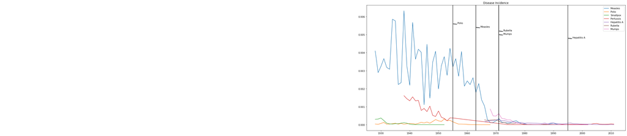

```python
fig = plt.figure(figsize=(20,10))

for frame in [measles_incidence, polio_incidence, smallpox_incidence, pertussis_incidence, hepa_incidence, rubella_incidence, mumps_incidence]:
    plt.plot(frame['year'], frame['incidence'])

ymin, ymax = plt.ylim()

for i in range(0, len(vaccine_df)): #this plots vertical lines where the vaccines came out
  plt.axvline(x=vaccine_df.iloc[i].Year, color = 'black')
  plt.annotate(s = f'{vaccine_df.iloc[i].Disease}', xy=(vaccine_df.iloc[i].Year, 0.006 - i*0.0002), xytext=(20, 0.0055), textcoords='offset points', annotation_clip=True, arrowprops={'width': 1, 'headwidth': 1, 'headlength': 1, 'shrink':0.05})

plt.legend(["Measles", "Polio", "Smallpox", "Pertussis", "Hepatitis A", "Rubella", "Mumps"]);
plt.title("Disease Incidence")
plt.xlim(1925, 2015) #we have to cut off the limits because 2 of the vaccines appeared way before 1930 and make the graph hard to read
```

Incidence analysis

```python
#vaccination data

#measles http://immunizationdata.who.int/pages/coverage/mcv.html?CODE=USA&ANTIGEN=MCV1&YEAR=

#general vaccination information from the CDC https://www.cdc.gaov/vaccines/pubs/pinkbook/meas.html#:~:text=The%20first%20live%2C%20attenuated%20vaccine,(MMRV)%20vaccine%20was%20licensed.
```

### Preliminary Data Analysis - National and State to State Incidence

Now that we have a solid idea of what the trends look like on a national scale, we can zoom back in to look at individual states to try and see how they compare.

#### Preparing a Dataset for Graphing

Cartographic Boundary Files - Shapefile of the United States: https://www.sciencebase.gov/catalog/item/52c78623e4b060b9ebca5be5

We originally got our data from the US Census, but there was too much data (each state had multiple coordinates for its regions). We found this dataset from sciencebase.gov, which is a U.S. Geological Survey Trusted Digital Repository. Their files are simpler and contain single coordinates for each state. We want only one row of data for each state so that we can easily join our data with our other datasets.

We followed these tutorials to implement our code:

https://mohammadimranhasan.com/geospatial-data-mapping-with-python/

https://towardsdatascience.com/lets-make-a-map-using-geopandas-pandas-and-matplotlib-to-make-a-chloropleth-map-dddc31c1983d

First, we need to install geopandas in order to create maps and import our coordinates file.

```python
!pip install geopandas
#!pip install --upgrade pyshp
#!pip install --upgrade shapely
#!pip install --upgrade descartes
```

```
     |████████████████████████████████| 1.0 MB 13.9 MB/s
     |████████████████████████████████| 16.7 MB 69.0 MB/s
     |████████████████████████████████| 6.3 MB 59.1 MB/s
```

We need to read in the zip file.

```python
import geopandas
states = geopandas.read_file("tl_2012_us_state.zip")

states.head()
```

|  | OBJECTID | REGION | DIVISION | STATEFP | STATENS | GEOID | STUSPS | NAME | LSAD | MTFCC | FUNCSTAT | ALAND | AWATER | INTPTLAT | INTPTLON | Shape_Leng | Shape_Area | geometry |
| --- | --- | --- | --- | --- | --- | --- | --- | --- | --- | --- | --- | --- | --- | --- | --- | --- | --- | --- |
| 0 | 1 | 4 | 9 | 15 | 01779782 | 15 | HI | Hawaii | 00 | G4000 | A | 1.663425e+10 | 1.167874e+10 | +19.8097670 | -155.5061027 | 2.419034e+06 | 3.268482e+10 | MULTIPOLYGON (((-17361760.204 2164544.588, -17... |
| 1 | 2 | 3 | 7 | 05 | 00068085 | 05 | AR | Arkansas | 00 | G4000 | A | 1.347726e+11 | 2.959210e+09 | +34.8955256 | -092.4446262 | 2.656648e+06 | 2.053261e+11 | POLYGON ((-10515267.713 4101325.818, -10515269... |
| 2 | 3 | 4 | 8 | 35 | 00897535 | 35 | NM | New Mexico | 00 | G4000 | A | 3.141611e+11 | 7.564385e+08 | +34.4346843 | -106.1316181 | 2.900368e+06 | 4.643927e+11 | POLYGON ((-12138963.727 4106855.170, -12138964... |
| 3 | 4 | 4 | 8 | 30 | 00767982 | 30 | MT | Montana | 00 | G4000 | A | 3.769636e+11 | 3.868565e+09 | +47.0511771 | -109.6348174 | 4.607246e+06 | 8.201836e+11 | POLYGON ((-12727480.235 5886876.586, -12727567... |
| 4 | 5 | 1 | 2 | 36 | 01779796 | 36 | NY | New York | 00 | G4000 | A | 1.220579e+11 | 1.923885e+10 | +42.9133974 | -075.5962723 | 3.212630e+06 | 2.637702e+11 | MULTIPOLYGON (((-8866092.533 5160809.769, -886... |

**Cleaning up the dataset**

There are some columns we don't need, and we can rename the columns to make them look neater.

```python
states.columns.unique() #grabbing column names
```

```
Index(['OBJECTID', 'REGION', 'DIVISION', 'STATEFP', 'STATENS', 'GEOID',
       'STUSPS', 'NAME', 'LSAD', 'MTFCC', 'FUNCSTAT', 'ALAND', 'AWATER',
       'INTPTLAT', 'INTPTLON', 'Shape_Leng', 'Shape_Area', 'geometry'],
      dtype='object')
```

```python
states.drop(columns=['OBJECTID', 'REGION', 'DIVISION', 'STATEFP', 'STATENS', 'GEOID',
       'STUSPS', 'LSAD', 'MTFCC', 'FUNCSTAT', 'ALAND', 'AWATER',
       'INTPTLAT', 'INTPTLON', 'Shape_Leng', 'Shape_Area'], inplace=True) #dropping unnecessary columns
states.rename(columns={'NAME':'State', 'geometry': 'Geometry'}, inplace=True) #renaming the columns to make them look prettier
states['State'] = states['State'].str.upper() #in order to join with previous datasets we want this to match
states.head()
```

|  | State | Geometry |
| --- | --- | --- |
| 0 | HAWAII | MULTIPOLYGON (((-17361760.204 2164544.588, -17... |
| 1 | ARKANSAS | POLYGON ((-10515267.713 4101325.818, -10515269... |
| 2 | NEW MEXICO | POLYGON ((-12138963.727 4106855.170, -12138964... |
| 3 | MONTANA | POLYGON ((-12727480.235 5886876.586, -12727567... |
| 4 | NEW YORK | MULTIPOLYGON (((-8866092.533 5160809.769, -886... |

```python
states.shape[0]
```

```
56
```

From the code above, we see that there are 56 rows, even though we know there are 50 states. By looking at the data, we see acquired regions of the US included, such as Puerto Rico and Guam. We need to keep this in mind for joining our data.

We need to check for NaN values.

```python
states.isnull().sum()
```

```
State       0
Geometry    0
dtype: int64
```

Perfect! We have no NaN values.

Just to test that we are using GeoPandas correctly, here is a simple map of the US.

```
(0.0, 12000000.0)
```

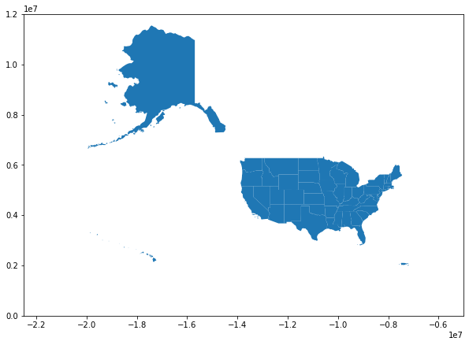

```python
states = geopandas.GeoDataFrame(states, geometry='Geometry') #turning the dataframe into a geodataframe object
states.plot(figsize=(10, 10))
plt.xlim(-2.25e7, -0.5e7)
plt.ylim(0.0, 1.2e7)
```

Great! We are good to move on with analysis. This work will be reffered to later in the seperate sections for national incidence of each disease

#### Measles

Great! We are good to move on with analysis.

We will now make a dataset that is usable for making a visual map.

```python
from matplotlib import legend
#for clean data, we will continue to do do seperate operations for each disease type

#create a dictionary of dataframs for every state
states_measles = dict()
for k, v in measles.groupby('loc'):
  states_measles[k] = v

#create an incidence column for every dataframe in the dictionary
for i in states_measles:
  states_measles[i]['incidence'] = states_measles[i]['number']/states_measles[i]['population']
  #set the index to year for easy combining later
  states_measles[i].set_index('year', inplace = True)

#create new dataframe of all of the incidences by state for every year
states_measles_incidence = pd.DataFrame()

#enter the incidence columns from the state datasets into the incidence dataset
for i in states_measles:
  states_measles_incidence[i] = states_measles[i]['incidence']

states_measles_incidence
```

| year | ALABAMA | ALASKA | ARIZONA | ARKANSAS | CALIFORNIA | COLORADO | CONNECTICUT | DELAWARE | DISTRICT OF COLUMBIA | FLORIDA | ... | SOUTH DAKOTA | TENNESSEE | TEXAS | UTAH | VERMONT | VIRGINIA | WASHINGTON | WEST VIRGINIA | WISCONSIN | WYOMING |
| --- | --- | --- | --- | --- | --- | --- | --- | --- | --- | --- | --- | --- | --- | --- | --- | --- | --- | --- | --- | --- | --- |
| 1928 | 3.349621e-03 | NaN | 2.007109e-03 | 0.004818 | 6.919910e-04 | 0.002070 | 0.006350 | 0.002562 | 0.005357 | 1.196092e-03 | ... | 0.001601 | 3.153963e-03 | 9.733921e-04 | 1.686508e-04 | 0.003349 | NaN | 0.003448 | 1.959316e-03 | 0.001246 | 0.002273 |
| 1929 | 1.119138e-03 | NaN | 5.488372e-04 | 0.000672 | 7.275357e-04 | 0.000742 | 0.006148 | 0.002398 | 0.000942 | 7.799308e-04 | ... | 0.001678 | 3.302611e-04 | 7.127733e-04 | 6.889764e-04 | 0.001053 | NaN | 0.002486 | 3.801398e-03 | 0.010165 | 0.003121 |
| 1930 | 1.570079e-03 | NaN | 4.663594e-03 | 0.000535 | 7.602171e-03 | 0.011328 | 0.001122 | 0.001092 | 0.001822 | 3.565602e-03 | ... | 0.003463 | 1.799160e-03 | 7.315195e-04 | 1.044794e-02 | 0.002367 | NaN | 0.006316 | 1.577034e-03 | 0.007485 | 0.003416 |
| 1931 | 3.372593e-03 | NaN | 4.976690e-03 | 0.000459 | 4.774554e-03 | 0.004533 | 0.007905 | 0.010033 | 0.008329 | 2.608171e-03 | ... | 0.002124 | 1.347761e-03 | 3.954630e-04 | 2.982456e-04 | 0.003184 | NaN | 0.001974 | 2.913793e-03 | 0.005066 | 0.000607 |
| 1932 | 1.017716e-04 | NaN | 2.018779e-04 | 0.000054 | 2.140821e-03 | 0.002229 | 0.003483 | 0.000159 | 0.000532 | 1.360947e-04 | ... | 0.000964 | 6.897824e-04 | 7.656433e-04 | 1.392650e-04 | 0.011461 | 5.338499e-04 | 0.006319 | 5.996566e-03 | 0.009353 | 0.002422 |
| ... | ... | ... | ... | ... | ... | ... | ... | ... | ... | ... | ... | ... | ... | ... | ... | ... | ... | ... | ... | ... | ... |
| 1991 | 2.439527e-07 | 0.000002 | 9.027138e-05 | NaN | 6.442247e-05 | 0.000003 | 0.000007 | 0.000028 | NaN | 2.221425e-05 | ... | NaN | 2.013455e-06 | 1.230026e-05 | 1.236108e-04 | 0.000007 | 3.332690e-06 | 0.000015 | NaN | 0.000001 | 0.000007 |
| 1993 | 2.372928e-07 | NaN | 7.379275e-07 | NaN | 2.014393e-06 | 0.000000 | 0.000002 | 0.000003 | NaN | 1.938655e-06 | ... | NaN | 0.000000e+00 | 5.506119e-07 | NaN | 0.000054 | NaN | NaN | NaN | 0.000000 | NaN |
| 1997 | 1.373647e-06 | 0.000002 | 1.899941e-06 | 0.000001 | 1.077387e-06 | 0.000007 | 0.000000 | NaN | 0.000004 | 5.267905e-07 | ... | 0.000012 | 5.455306e-07 | 4.559197e-07 | 4.717462e-07 | 0.000099 | 2.928608e-07 | 0.000003 | 5.497185e-07 | 0.000000 | 0.000006 |
| 1998 | 0.000000e+00 | 0.000026 | 2.047778e-06 | NaN | 1.212574e-07 | NaN | NaN | 0.000000 | NaN | 6.457212e-08 | ... | NaN | 0.000000e+00 | NaN | NaN | 0.000000 | 0.000000e+00 | 0.000000 | NaN | 0.000000 | NaN |
| 2002 | 1.565148e-06 | NaN | NaN | NaN | 0.000000e+00 | NaN | NaN | NaN | NaN | 5.995093e-08 | ... | NaN | NaN | 4.606005e-08 | 0.000000e+00 | NaN | NaN | NaN | NaN | NaN | NaN |

66 rows × 51 columns

We are now ready to pull on the earlier dataframe we made earlier to create a heat map representation of the data

```python
map_measles_df = states_measles_incidence.T #transpose to get states in a column
map_measles_df.reset_index(inplace=True)
map_measles_df.rename(columns={'index':'State'}, inplace=True)
map_measles_df = pd.merge(map_measles_df, states, on="State", how='left') #we want to use the keys of the incidence values because we know those are 50 states, not including Guam, etc.
map_measles_df.head()
```

|  | State | 1928 | 1929 | 1930 | 1931 | 1932 | 1933 | 1934 | 1935 | 1936 | ... | 1987 | 1988 | 1989 | 1990 | 1991 | 1993 | 1997 | 1998 | 2002 | Geometry |
| --- | --- | --- | --- | --- | --- | --- | --- | --- | --- | --- | --- | --- | --- | --- | --- | --- | --- | --- | --- | --- | --- |
| 0 | ALABAMA | 0.003350 | 0.001119 | 0.001570 | 0.003373 | 0.000102 | 0.000652 | 0.005903 | 0.002653 | 0.000208 | ... | 9.940743e-07 | 2.481253e-07 | 0.000015 | 0.000007 | 2.439527e-07 | 2.372928e-07 | 0.000001 | 0.000000e+00 | 0.000002 | POLYGON ((-9841333.855 3579579.495, -9841349.6... |
| 1 | ALASKA | NaN | NaN | NaN | NaN | NaN | NaN | NaN | NaN | NaN | ... | NaN | 1.827622e-06 | 0.000000 | 0.000049 | 1.753792e-06 | NaN | 0.000002 | 2.580928e-05 | NaN | MULTIPOLYGON (((-15108567.654 8339788.089, -15... |
| 2 | ARIZONA | 0.002007 | 0.000549 | 0.004664 | 0.004977 | 0.000202 | 0.002960 | 0.002388 | 0.001350 | 0.005255 | ... | 9.900478e-06 | 8.282294e-07 | 0.000040 | 0.000077 | 9.027138e-05 | 7.379275e-07 | 0.000002 | 2.047778e-06 | NaN | POLYGON ((-12761162.105 4147165.875, -12761214... |
| 3 | ARKANSAS | 0.004818 | 0.000672 | 0.000535 | 0.000459 | 0.000054 | 0.002933 | 0.003846 | 0.000803 | 0.000057 | ... | NaN | NaN | 0.000002 | 0.000017 | NaN | NaN | 0.000001 | NaN | NaN | POLYGON ((-10515267.713 4101325.818, -10515269... |
| 4 | CALIFORNIA | 0.000692 | 0.000728 | 0.007602 | 0.004775 | 0.002141 | 0.004453 | 0.004233 | 0.004664 | 0.007735 | ... | 2.719200e-05 | 2.515558e-05 | 0.000074 | 0.000320 | 6.442247e-05 | 2.014393e-06 | 0.000001 | 1.212574e-07 | 0.000000 | MULTIPOLYGON (((-13060108.516 3854208.959, -13... |

5 rows × 68 columns

Here, we take in user input to plot the map for a certain year of their choosing:

```
What year would you like to display (between 1928 and 2002? 1953
```

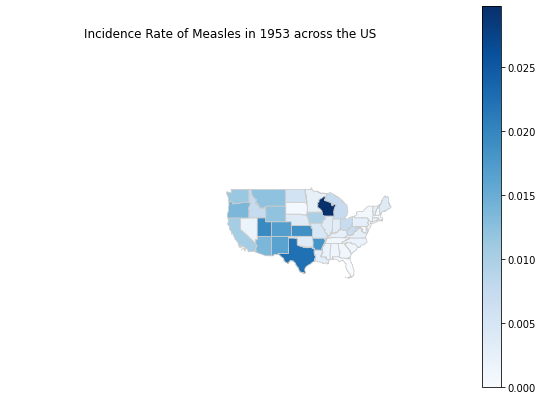

```python
sel = str(input("What year would you like to display (between 1928 and 2002? ")) #take in input
sel = int(sel) #turn into an integer for later

map_measles_df = geopandas.GeoDataFrame(map_measles_df, geometry='Geometry') #turning the dataframe into a geodataframe object to be used with geopandas to plot

#Here we are trying to find the min and max values to use for our scalebar
#We don't want to do this for each year because looking at the graph over time would be misleading if you kept changing the scalebars
map_measles_df.columns.unique()
merged_cols = map_measles_df.columns.unique()

merged_cols = merged_cols[1:-1] #only grabbing the years
vmin = map_measles_df[merged_cols].min().min()
vmax = map_measles_df[merged_cols].max().max()

#Plotting
fig, ax = plt.subplots(1, figsize=(10,7))
map_measles_df.plot(column=sel, figsize=(10, 7), cmap='Blues', linewidth=0.8, ax=ax, edgecolor='0.8')
plt.xlim(-2.25e7, -0.5e7) #resetting axes
plt.ylim(0.5, 1.2e7)
ax.axis('off') #remove axis because it means nothing for us

ax.set_title(f'Incidence Rate of Measles in {sel} across the US')

sm = plt.cm.ScalarMappable(cmap='Blues', norm=plt.Normalize(vmin=vmin, vmax=vmax)) #for color scalebar
sm._A = []
cbar = fig.colorbar(sm)
```

Now that we hve this incidence for each state, we can compare them to the national incidences to see if there are any states that experienced a higher rate than nationally. We can also just compare ampng the states to see which states experienced the highest and lowest incidence rate over the years.

#### Polio

```python
from matplotlib import legend
#for clean data, we will continue to do do seperate operations for each disease type

#create a dictionary of dataframs for every state
states_polio = dict()
for k, v in polio.groupby('loc'):
  states_polio[k] = v

#create an incidence column for every dataframe in the dictionary
for i in states_polio:
  states_polio[i]['incidence'] = states_polio[i]['number']/states_polio[i]['population']
  #set the index to year for easy combining later
  states_polio[i].set_index('year', inplace = True)

#create new dataframe of all of the incidences by state for every year
states_polio_incidence = pd.DataFrame()

#enter the incidence columns from the state datasets into the incidence dataset
for i in states_polio:
  states_polio_incidence[i] = states_polio[i]['incidence']

states_polio_incidence.head()
```

| year | ALABAMA | ALASKA | ARIZONA | ARKANSAS | CALIFORNIA | COLORADO | CONNECTICUT | DELAWARE | DISTRICT OF COLUMBIA | FLORIDA | ... | SOUTH DAKOTA | TENNESSEE | TEXAS | UTAH | VERMONT | VIRGINIA | WASHINGTON | WEST VIRGINIA | WISCONSIN | WYOMING |
| --- | --- | --- | --- | --- | --- | --- | --- | --- | --- | --- | --- | --- | --- | --- | --- | --- | --- | --- | --- | --- | --- |
| 1928 | 0.000023 | NaN | 0.000026 | 0.000005 | 0.000051 | 0.000070 | 0.000046 | 0.000034 | 0.000069 | 0.000015 | ... | 0.000064 | 0.000013 | 0.000007 | 0.000018 | 0.000073 | 0.000006 | 0.000208 | 0.000114 | 0.000017 | 0.000027 |
| 1929 | 0.000022 | NaN | 0.000021 | 0.000002 | 0.000028 | 0.000013 | 0.000013 | 0.000021 | 0.000012 | 0.000024 | ... | 0.000004 | 0.000036 | 0.000003 | 0.000008 | 0.000053 | 0.000099 | 0.000017 | 0.000034 | 0.000007 | 0.000013 |
| 1930 | 0.000025 | NaN | 0.000074 | 0.000042 | 0.000307 | 0.000063 | 0.000046 | 0.000025 | 0.000018 | 0.000008 | ... | 0.000202 | 0.000023 | 0.000022 | 0.000006 | 0.000008 | 0.000005 | 0.000030 | 0.000024 | 0.000061 | 0.000243 |
| 1931 | 0.000020 | NaN | 0.000026 | 0.000009 | 0.000043 | 0.000009 | 0.000700 | 0.000021 | 0.000030 | 0.000011 | ... | 0.000042 | 0.000018 | 0.000006 | 0.000010 | 0.000248 | 0.000010 | 0.000054 | 0.000047 | 0.000246 | 0.000026 |
| 1932 | 0.000013 | NaN | 0.000016 | 0.000008 | 0.000029 | 0.000008 | 0.000020 | 0.000045 | 0.000066 | 0.000005 | ... | 0.000022 | 0.000020 | 0.000012 | 0.000006 | 0.000006 | 0.000022 | 0.000047 | 0.000025 | 0.000019 | 0.000026 |

5 rows × 51 columns

```python
map_polio_df = states_polio_incidence.T #transpose to get states in a column
map_polio_df.reset_index(inplace=True)
map_polio_df.rename(columns={'index':'State'}, inplace=True)
map_polio_df = pd.merge(map_polio_df, states, on="State", how='left') #we want to use the keys of the incidence values because we know those are 50 states, not including Guam, etc.
map_polio_df.head()
```

|  | State | 1928 | 1929 | 1930 | 1931 | 1932 | 1933 | 1934 | 1935 | 1936 | ... | 1958 | 1959 | 1960 | 1961 | 1962 | 1963 | 1964 | 1966 | 1968 | Geometry |
| --- | --- | --- | --- | --- | --- | --- | --- | --- | --- | --- | --- | --- | --- | --- | --- | --- | --- | --- | --- | --- | --- |
| 0 | ALABAMA | 0.000023 | 0.000022 | 0.000025 | 0.000020 | 0.000013 | 0.000011 | 0.000019 | 0.000022 | 0.000153 | ... | 0.000020 | 0.000048 | 0.000007 | 0.000003 | 0.000007 | 0.000016 | 5.891016e-07 | 0.000000e+00 | 2.901915e-07 | POLYGON ((-9841333.855 3579579.495, -9841349.6... |
| 1 | ALASKA | NaN | NaN | NaN | NaN | NaN | NaN | NaN | NaN | NaN | ... | 0.000009 | 0.000089 | 0.000009 | NaN | NaN | NaN | NaN | NaN | NaN | MULTIPOLYGON (((-15108567.654 8339788.089, -15... |
| 2 | ARIZONA | 0.000026 | 0.000021 | 0.000074 | 0.000026 | 0.000016 | 0.000038 | 0.000257 | 0.000048 | 0.000020 | ... | 0.000028 | 0.000049 | 0.000007 | 0.000006 | 0.000004 | 0.000002 | NaN | NaN | 5.945303e-07 | POLYGON ((-12761162.105 4147165.875, -12761214... |
| 3 | ARKANSAS | 0.000005 | 0.000002 | 0.000042 | 0.000009 | 0.000008 | 0.000007 | 0.000007 | 0.000015 | 0.000030 | ... | 0.000024 | 0.000110 | 0.000023 | 0.000014 | 0.000014 | 0.000003 | NaN | 5.265929e-07 | 5.257624e-07 | POLYGON ((-10515267.713 4101325.818, -10515269... |
| 4 | CALIFORNIA | 0.000051 | 0.000028 | 0.000307 | 0.000043 | 0.000029 | 0.000025 | 0.000540 | 0.000126 | 0.000059 | ... | 0.000021 | 0.000022 | 0.000026 | 0.000006 | 0.000005 | 0.000001 | 1.101868e-07 | 1.590837e-07 | 5.671857e-07 | MULTIPOLYGON (((-13060108.516 3854208.959, -13... |

5 rows × 41 columns

```
What year would you like to display (between 1928 and 1968? 1953
```

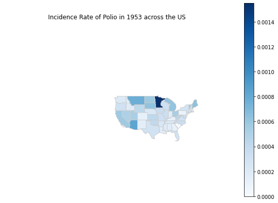

```python
sel = str(input("What year would you like to display (between 1928 and 1968? ")) #take in input
sel = int(sel) #turn into an integer for later

map_polio_df = geopandas.GeoDataFrame(map_polio_df, geometry='Geometry') #turning the dataframe into a geodataframe object to be used with geopandas to plot

#Here we are trying to find the min and max values to use for our scalebar
#We don't want to do this for each year because looking at the graph over time would be misleading if you kept changing the scalebars
map_polio_df.columns.unique()
merged_cols = map_polio_df.columns.unique()

merged_cols = merged_cols[1:-1] #only grabbing the years
vmin = map_polio_df[merged_cols].min().min()
vmax = map_polio_df[merged_cols].max().max()

#Plotting
fig, ax = plt.subplots(1, figsize=(10,7))
map_polio_df.plot(column=sel, figsize=(10, 7), cmap='Blues', linewidth=0.8, ax=ax, edgecolor='0.8')
plt.xlim(-2.25e7, -0.5e7) #resetting axes
plt.ylim(0.5, 1.2e7)
ax.axis('off') #remove axis because it means nothing for us

ax.set_title(f'Incidence Rate of Polio in {sel} across the US')

sm = plt.cm.ScalarMappable(cmap='Blues', norm=plt.Normalize(vmin=vmin, vmax=vmax)) #for color scalebar
sm._A = []
cbar = fig.colorbar(sm)
```

#### Pertussis

```python
from matplotlib import legend
#for clean data, we will continue to do do seperate operations for each disease type

#create a dictionary of dataframs for every state
states_pertussis = dict()
for k, v in pertussis.groupby('loc'):
  states_pertussis[k] = v

#create an incidence column for every dataframe in the dictionary
for i in states_pertussis:
  states_pertussis[i]['incidence'] = states_pertussis[i]['number']/states_pertussis[i]['population']
  #set the index to year for easy combining later
  states_pertussis[i].set_index('year', inplace = True)

#create new dataframe of all of the incidences by state for every year
states_pertussis_incidence = pd.DataFrame()

#enter the incidence columns from the state datasets into the incidence dataset
for i in states_pertussis:
  states_pertussis_incidence[i] = states_pertussis[i]['incidence']

states_pertussis_incidence.head()
```

| year | ALABAMA | ALASKA | ARIZONA | ARKANSAS | CALIFORNIA | COLORADO | CONNECTICUT | DELAWARE | DISTRICT OF COLUMBIA | FLORIDA | ... | SOUTH DAKOTA | TENNESSEE | TEXAS | UTAH | VERMONT | VIRGINIA | WASHINGTON | WEST VIRGINIA | WISCONSIN | WYOMING |
| --- | --- | --- | --- | --- | --- | --- | --- | --- | --- | --- | --- | --- | --- | --- | --- | --- | --- | --- | --- | --- | --- |
| 1938 | 0.000661 | NaN | 0.003489 | 0.000804 | 0.002271 | 0.001477 | 0.002166 | 0.002292 | 0.000925 | 0.000458 | ... | 0.001160 | 0.000736 | 0.001573 | 0.004725 | 0.006935 | 0.001475 | 0.002615 | 0.001649 | 0.004112 | 0.002272 |
| 1939 | 0.000702 | NaN | 0.002138 | 0.000483 | 0.001245 | 0.001817 | 0.002378 | 0.002897 | 0.002271 | 0.000607 | ... | 0.000419 | 0.000785 | 0.000870 | 0.005843 | 0.008475 | 0.001275 | 0.000945 | 0.000809 | 0.003520 | 0.001907 |
| 1940 | 0.000434 | NaN | 0.001788 | 0.000415 | 0.001823 | 0.001107 | 0.001799 | 0.002264 | 0.001094 | 0.000349 | ... | 0.000284 | 0.000722 | 0.001278 | 0.007196 | 0.003793 | 0.001134 | 0.001164 | 0.000966 | 0.002249 | 0.000828 |
| 1941 | 0.000540 | NaN | 0.002400 | 0.000568 | 0.002622 | 0.004182 | 0.001591 | 0.001004 | 0.000937 | 0.000371 | ... | 0.000954 | 0.000865 | 0.001620 | 0.005018 | 0.001828 | 0.001467 | 0.002582 | 0.001201 | 0.002861 | 0.001534 |
| 1942 | 0.000558 | NaN | 0.002048 | 0.000464 | 0.001556 | 0.001626 | 0.002181 | 0.000545 | 0.001090 | 0.000381 | ... | 0.000411 | 0.000656 | 0.001155 | 0.002614 | 0.006061 | 0.000847 | 0.001579 | 0.000765 | 0.003420 | 0.001382 |

5 rows × 51 columns

```python
map_pertussis_df = states_pertussis_incidence.T #transpose to get states in a column
map_pertussis_df.reset_index(inplace=True)
map_pertussis_df.rename(columns={'index':'State'}, inplace=True)
map_pertussis_df = pd.merge(map_pertussis_df, states, on="State", how='left') #we want to use the keys of the incidence values because we know those are 50 states, not including Guam, etc.
map_pertussis_df.head()
```

|  | State | 1938 | 1939 | 1940 | 1941 | 1942 | 1943 | 1944 | 1945 | 1946 | ... | 2003 | 2004 | 2005 | 2006 | 2007 | 2008 | 2009 | 2010 | 2011 | Geometry |
| --- | --- | --- | --- | --- | --- | --- | --- | --- | --- | --- | --- | --- | --- | --- | --- | --- | --- | --- | --- | --- | --- |
| 0 | ALABAMA | 0.000661 | 0.000702 | 0.000434 | 0.000540 | 0.000558 | 0.000708 | 0.000469 | 0.000390 | 0.000360 | ... | 0.000003 | 0.000009 | 0.000018 | 0.000020 | 0.000016 | 0.000011 | 0.000035 | 0.000024 | 0.000022 | POLYGON ((-9841333.855 3579579.495, -9841349.6... |
| 1 | ALASKA | NaN | NaN | NaN | NaN | NaN | NaN | NaN | NaN | NaN | ... | 0.000009 | 0.000017 | 0.000184 | 0.000078 | 0.000054 | 0.000278 | 0.000100 | 0.000059 | 0.000037 | MULTIPOLYGON (((-15108567.654 8339788.089, -15... |
| 2 | ARIZONA | 0.003489 | 0.002138 | 0.001788 | 0.002400 | 0.002048 | 0.001366 | 0.001598 | 0.001436 | 0.001135 | ... | 0.000016 | 0.000036 | 0.000159 | 0.000057 | 0.000031 | 0.000016 | 0.000023 | 0.000027 | 0.000041 | POLYGON ((-12761162.105 4147165.875, -12761214... |
| 3 | ARKANSAS | 0.000804 | 0.000483 | 0.000415 | 0.000568 | 0.000464 | 0.000794 | 0.000552 | 0.000392 | 0.000271 | ... | 0.000011 | 0.000028 | 0.000104 | 0.000021 | 0.000030 | 0.000020 | 0.000036 | 0.000023 | 0.000017 | POLYGON ((-10515267.713 4101325.818, -10515269... |
| 4 | CALIFORNIA | 0.002271 | 0.001245 | 0.001823 | 0.002622 | 0.001556 | 0.001501 | 0.000620 | 0.001200 | 0.000424 | ... | 0.000018 | 0.000014 | 0.000045 | 0.000023 | 0.000003 | 0.000008 | 0.000011 | 0.000034 | 0.000030 | MULTIPOLYGON (((-13060108.516 3854208.959, -13... |

5 rows × 57 columns

```
What year would you like to display (between 1938 and 2011? 1953
```

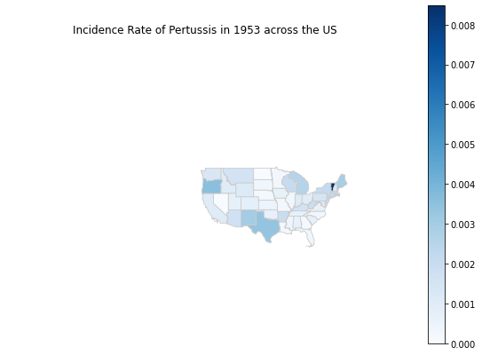

```python
sel = str(input("What year would you like to display (between 1938 and 2011? ")) #take in input
sel = int(sel) #turn into an integer for later

map_pertussis_df = geopandas.GeoDataFrame(map_pertussis_df, geometry='Geometry') #turning the dataframe into a geodataframe object to be used with geopandas to plot

#Here we are trying to find the min and max values to use for our scalebar
#We don't want to do this for each year because looking at the graph over time would be misleading if you kept changing the scalebars
map_pertussis_df.columns.unique()
merged_cols = map_pertussis_df.columns.unique()

merged_cols = merged_cols[1:-1] #only grabbing the years
vmin = map_pertussis_df[merged_cols].min().min()
vmax = map_pertussis_df[merged_cols].max().max()

#Plotting
fig, ax = plt.subplots(1, figsize=(10,7))
map_pertussis_df.plot(column=sel, figsize=(10, 7), cmap='Blues', linewidth=0.8, ax=ax, edgecolor='0.8')
plt.xlim(-2.25e7, -0.5e7) #resetting axes
plt.ylim(0.5, 1.2e7)
ax.axis('off') #remove axis because it means nothing for us

ax.set_title(f'Incidence Rate of Pertussis in {sel} across the US')

sm = plt.cm.ScalarMappable(cmap='Blues', norm=plt.Normalize(vmin=vmin, vmax=vmax)) #for color scalebar
sm._A = []
cbar = fig.colorbar(sm)
```

#### Hepatitis A

```python
from matplotlib import legend
#for clean data, we will continue to do do seperate operations for each disease type

#create a dictionary of dataframs for every state
states_hepa = dict()
for k, v in hepa.groupby('loc'):
  states_hepa[k] = v

#create an incidence column for every dataframe in the dictionary
for i in states_hepa:
  states_hepa[i]['incidence'] = states_hepa[i]['number']/states_hepa[i]['population']
  #set the index to year for easy combining later
  states_hepa[i].set_index('year', inplace = True)

#create new dataframe of all of the incidences by state for every year
states_hepa_incidence = pd.DataFrame()

#enter the incidence columns from the state datasets into the incidence dataset
for i in states_hepa:
  states_hepa_incidence[i] = states_hepa[i]['incidence']

states_hepa_incidence.head()
```

| year | ALABAMA | ALASKA | ARIZONA | ARKANSAS | CALIFORNIA | COLORADO | CONNECTICUT | DELAWARE | DISTRICT OF COLUMBIA | FLORIDA | ... | SOUTH DAKOTA | TENNESSEE | TEXAS | UTAH | VERMONT | VIRGINIA | WASHINGTON | WEST VIRGINIA | WISCONSIN | WYOMING |
| --- | --- | --- | --- | --- | --- | --- | --- | --- | --- | --- | --- | --- | --- | --- | --- | --- | --- | --- | --- | --- | --- |
| 1966 | 0.000093 | 0.000332 | 0.000257 | 0.000157 | 0.000315 | 0.000145 | 0.000115 | 0.000153 | 0.000048 | 0.000106 | ... | 0.000020 | 0.000261 | 0.000172 | 0.000168 | 0.000056 | 0.000130 | 0.000189 | 0.000137 | 0.000088 | 0.000167 |
| 1967 | 0.000084 | 0.000140 | 0.000237 | 0.000155 | 0.000390 | 0.000143 | 0.000199 | 0.000330 | 0.000053 | 0.000103 | ... | 0.000019 | 0.000217 | 0.000257 | 0.000155 | 0.000035 | 0.000157 | 0.000277 | 0.000205 | 0.000104 | 0.000202 |
| 1968 | 0.000091 | 0.000295 | 0.000253 | 0.000087 | 0.000558 | 0.000337 | 0.000169 | 0.000273 | 0.000086 | 0.000173 | ... | 0.000115 | 0.000267 | 0.000202 | 0.000252 | 0.000156 | 0.000127 | 0.000364 | 0.000189 | 0.000125 | 0.000114 |
| 1969 | 0.000110 | 0.000213 | 0.000304 | 0.000099 | 0.000459 | 0.000271 | 0.000206 | 0.000124 | 0.000076 | 0.000204 | ... | 0.000129 | 0.000260 | 0.000209 | 0.000271 | 0.000341 | 0.000093 | 0.000377 | 0.000194 | 0.000095 | 0.000246 |
| 1970 | 0.000118 | 0.000358 | 0.000324 | 0.000107 | 0.000463 | 0.000397 | 0.000281 | 0.000239 | 0.000116 | 0.000252 | ... | 0.000031 | 0.000316 | 0.000238 | 0.000282 | 0.000808 | 0.000285 | 0.000399 | 0.000216 | 0.000108 | 0.000244 |

5 rows × 51 columns

```python
map_hepa_df = states_hepa_incidence.T #transpose to get states in a column
map_hepa_df.reset_index(inplace=True)
map_hepa_df.rename(columns={'index':'State'}, inplace=True)
map_hepa_df = pd.merge(map_hepa_df, states, on="State", how='left') #we want to use the keys of the incidence values because we know those are 50 states, not including Guam, etc.
map_hepa_df.head()
```

|  | State | 1966 | 1967 | 1968 | 1969 | 1970 | 1971 | 1972 | 1973 | 1974 | ... | 2003 | 2004 | 2005 | 2006 | 2007 | 2008 | 2009 | 2010 | 2011 | Geometry |
| --- | --- | --- | --- | --- | --- | --- | --- | --- | --- | --- | --- | --- | --- | --- | --- | --- | --- | --- | --- | --- | --- |
| 0 | ALABAMA | 0.000093 | 0.000084 | 0.000091 | 0.000110 | 0.000118 | 0.000107 | 0.000096 | 0.000129 | 0.000066 | ... | 0.000003 | 0.000001 | 0.000007 | 0.000004 | 0.000004 | 0.000002 | 0.000002 | 0.000002 | 0.000001 | POLYGON ((-9841333.855 3579579.495, -9841349.6... |
| 1 | ALASKA | 0.000332 | 0.000140 | 0.000295 | 0.000213 | 0.000358 | 0.000296 | 0.000602 | 0.000660 | 0.000659 | ... | 0.000012 | 0.000006 | 0.000004 | NaN | 0.000004 | 0.000004 | 0.000009 | 0.000006 | 0.000001 | MULTIPOLYGON (((-15108567.654 8339788.089, -15... |
| 2 | ARIZONA | 0.000257 | 0.000237 | 0.000253 | 0.000304 | 0.000324 | 0.000446 | 0.000311 | 0.000072 | 0.000224 | ... | 0.000042 | 0.000036 | 0.000040 | 0.000011 | 0.000026 | 0.000016 | 0.000011 | 0.000011 | 0.000003 | POLYGON ((-12761162.105 4147165.875, -12761214... |
| 3 | ARKANSAS | 0.000157 | 0.000155 | 0.000087 | 0.000099 | 0.000107 | 0.000117 | 0.000135 | 0.000067 | 0.000206 | ... | 0.000006 | 0.000019 | 0.000006 | 0.000008 | 0.000004 | 0.000001 | 0.000002 | 0.000000 | 0.000000 | POLYGON ((-10515267.713 4101325.818, -10515269... |
| 4 | CALIFORNIA | 0.000315 | 0.000390 | 0.000558 | 0.000459 | 0.000463 | 0.000467 | 0.000345 | 0.000325 | 0.000258 | ... | 0.000030 | 0.000022 | 0.000025 | 0.000019 | 0.000009 | 0.000009 | 0.000006 | 0.000005 | 0.000005 | MULTIPOLYGON (((-13060108.516 3854208.959, -13... |

5 rows × 48 columns

```
What year would you like to display (between 1966 and 2011? 1968
```

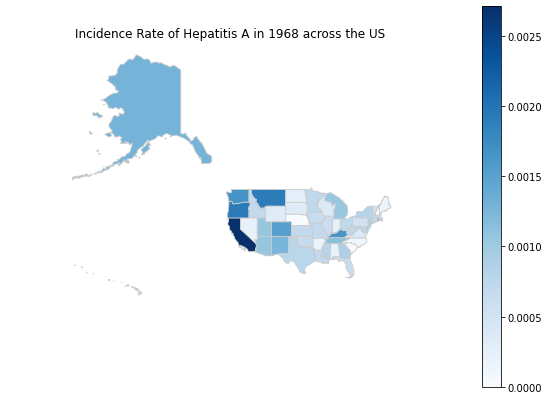

```python
sel = str(input("What year would you like to display (between 1966 and 2011? ")) #take in input
sel = int(sel) #turn into an integer for later

map_hepa_df = geopandas.GeoDataFrame(map_hepa_df, geometry='Geometry') #turning the dataframe into a geodataframe object to be used with geopandas to plot

#Here we are trying to find the min and max values to use for our scalebar
#We don't want to do this for each year because looking at the graph over time would be misleading if you kept changing the scalebars
map_hepa_df.columns.unique()
merged_cols = map_hepa_df.columns.unique()

merged_cols = merged_cols[1:-1] #only grabbing the years
vmin = map_hepa_df[merged_cols].min().min()
vmax = map_hepa_df[merged_cols].max().max()

#Plotting
fig, ax = plt.subplots(1, figsize=(10,7))
map_hepa_df.plot(column=sel, figsize=(10, 7), cmap='Blues', linewidth=0.8, ax=ax, edgecolor='0.8')
plt.xlim(-2.25e7, -0.5e7) #resetting axes
plt.ylim(0.5, 1.2e7)
ax.axis('off') #remove axis because it means nothing for us

ax.set_title(f'Incidence Rate of Hepatitis A in {sel} across the US')

sm = plt.cm.ScalarMappable(cmap='Blues', norm=plt.Normalize(vmin=vmin, vmax=vmax)) #for color scalebar
sm._A = []
cbar = fig.colorbar(sm)
```

#### Rubella

```python
from matplotlib import legend
#for clean data, we will continue to do do seperate operations for each disease type

#create a dictionary of dataframs for every state
states_rubella = dict()
for k, v in rubella.groupby('loc'):
  states_rubella[k] = v

#create an incidence column for every dataframe in the dictionary
for i in states_rubella:
  states_rubella[i]['incidence'] = states_rubella[i]['number']/states_rubella[i]['population']
  #set the index to year for easy combining later
  states_rubella[i].set_index('year', inplace = True)

#create new dataframe of all of the incidences by state for every year
states_rubella_incidence = pd.DataFrame()

#enter the incidence columns from the state datasets into the incidence dataset
for i in states_rubella:
  states_rubella_incidence[i] = states_rubella[i]['incidence']

states_rubella_incidence.head()
```

| year | ALABAMA | ALASKA | ARIZONA | ARKANSAS | CALIFORNIA | COLORADO | CONNECTICUT | DELAWARE | DISTRICT OF COLUMBIA | FLORIDA | ... | SOUTH DAKOTA | TENNESSEE | TEXAS | UTAH | VERMONT | VIRGINIA | WASHINGTON | WEST VIRGINIA | WISCONSIN | WYOMING |
| --- | --- | --- | --- | --- | --- | --- | --- | --- | --- | --- | --- | --- | --- | --- | --- | --- | --- | --- | --- | --- | --- |
| 1966 | 0.000032 | 0.000413 | 0.001595 | 0.000005 | 0.000149 | 0.000370 | 0.000756 | 0.000103 | 0.000019 | 0.000231 | ... | 0.000003 | 0.000676 | 0.000013 | 0.000080 | 0.000385 | 0.000216 | 0.001024 | 0.000573 | 0.001194 | 0.000740 |
| 1967 | 0.000062 | 0.001137 | 0.000593 | 0.000009 | 0.000473 | 0.000882 | 0.000622 | 0.000141 | 0.000009 | 0.000184 | ... | 0.000004 | 0.000333 | 0.000059 | 0.000080 | 0.000506 | 0.000144 | 0.000955 | 0.000334 | 0.000713 | 0.000012 |
| 1968 | 0.000117 | 0.001014 | 0.000416 | 0.000002 | 0.000252 | 0.000418 | 0.001025 | 0.000281 | 0.000018 | 0.000229 | ... | NaN | 0.000293 | 0.000265 | 0.000107 | 0.000212 | 0.000140 | 0.000561 | 0.000499 | 0.000686 | 0.000037 |
| 1969 | 0.000040 | 0.001574 | 0.000471 | 0.000104 | 0.000306 | 0.000635 | 0.000548 | 0.000365 | 0.000209 | 0.000299 | ... | NaN | 0.000428 | 0.000378 | 0.000146 | 0.000275 | 0.000334 | 0.000540 | 0.001348 | 0.000720 | 0.000246 |
| 1970 | 0.000109 | 0.000269 | 0.000328 | 0.000019 | 0.000258 | 0.000188 | 0.000203 | 0.000081 | 0.000028 | 0.000466 | ... | 0.000006 | 0.000381 | 0.000723 | 0.000157 | 0.000150 | 0.000162 | 0.001415 | 0.000800 | 0.000514 | 0.000400 |

5 rows × 51 columns

```python
map_rubella_df = states_rubella_incidence.T #transpose to get states in a column
map_rubella_df.reset_index(inplace=True)
map_rubella_df.rename(columns={'index':'State'}, inplace=True)
map_rubella_df = pd.merge(map_rubella_df, states, on="State", how='left') #we want to use the keys of the incidence values because we know those are 50 states, not including Guam, etc.
map_rubella_df.head()
```

|  | State | 1966 | 1967 | 1968 | 1969 | 1970 | 1971 | 1972 | 1973 | 1974 | ... | 1981 | 1983 | 1984 | 1989 | 1990 | 1996 | 1998 | 1999 | 2000 | Geometry |
| --- | --- | --- | --- | --- | --- | --- | --- | --- | --- | --- | --- | --- | --- | --- | --- | --- | --- | --- | --- | --- | --- |
| 0 | ALABAMA | 0.000032 | 0.000062 | 0.000117 | 0.000040 | 0.000109 | 0.000064 | 0.000019 | 0.000061 | 1.766874e-05 | ... | 2.547598e-07 | 2.530480e-07 | 7.551876e-07 | 2.474888e-07 | 2.469102e-07 | 4.617762e-07 | 0.000000e+00 | 2.257264e-07 | 6.738773e-07 | POLYGON ((-9841333.855 3579579.495, -9841349.6... |
| 1 | ALASKA | 0.000413 | 0.001137 | 0.001014 | 0.001574 | 0.000269 | 0.000126 | 0.000085 | 0.000085 | NaN | ... | 2.224170e-06 | 1.946654e-06 | 1.877952e-06 | NaN | NaN | NaN | NaN | NaN | NaN | MULTIPOLYGON (((-15108567.654 8339788.089, -15... |
| 2 | ARIZONA | 0.001595 | 0.000593 | 0.000416 | 0.000471 | 0.000328 | 0.000200 | 0.000173 | 0.000012 | 8.753321e-07 | ... | 7.612823e-06 | 2.608297e-06 | 1.256464e-06 | NaN | 8.414545e-06 | 2.180103e-07 | 4.095556e-07 | 2.189568e-06 | 1.935473e-07 | POLYGON ((-12761162.105 4147165.875, -12761214... |
| 3 | ARKANSAS | 0.000005 | 0.000009 | 0.000002 | 0.000104 | 0.000019 | 0.000167 | 0.000035 | 0.000049 | 3.704517e-06 | ... | 3.051097e-06 | NaN | 1.289188e-06 | 4.254007e-07 | 1.273028e-06 | NaN | NaN | 7.541876e-07 | NaN | POLYGON ((-10515267.713 4101325.818, -10515269... |
| 4 | CALIFORNIA | 0.000149 | 0.000473 | 0.000252 | 0.000306 | 0.000258 | 0.000407 | 0.000230 | 0.000119 | 6.639475e-05 | ... | 1.913779e-05 | 1.029237e-05 | 6.089003e-06 | 3.797040e-06 | 1.552095e-05 | 1.499118e-06 | 6.062870e-08 | 1.492573e-07 | 3.235811e-07 | MULTIPOLYGON (((-13060108.516 3854208.959, -13... |

5 rows × 26 columns

```
What year would you like to display (between 1966 and 2002? 1968
```

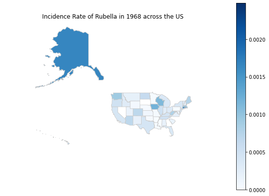

```python
sel = str(input("What year would you like to display (between 1966 and 2002? ")) #take in input
sel = int(sel) #turn into an integer for later

map_rubella_df = geopandas.GeoDataFrame(map_rubella_df, geometry='Geometry') #turning the dataframe into a geodataframe object to be used with geopandas to plot

#Here we are trying to find the min and max values to use for our scalebar
#We don't want to do this for each year because looking at the graph over time would be misleading if you kept changing the scalebars
map_rubella_df.columns.unique()
merged_cols = map_rubella_df.columns.unique()

merged_cols = merged_cols[1:-1] #only grabbing the years
vmin = map_rubella_df[merged_cols].min().min()
vmax = map_rubella_df[merged_cols].max().max()

#Plotting
fig, ax = plt.subplots(1, figsize=(10,7))
map_rubella_df.plot(column=sel, figsize=(10, 7), cmap='Blues', linewidth=0.8, ax=ax, edgecolor='0.8')
plt.xlim(-2.25e7, -0.5e7) #resetting axes
plt.ylim(0.5, 1.2e7)
ax.axis('off') #remove axis because it means nothing for us

ax.set_title(f'Incidence Rate of Rubella in {sel} across the US')

sm = plt.cm.ScalarMappable(cmap='Blues', norm=plt.Normalize(vmin=vmin, vmax=vmax)) #for color scalebar
sm._A = []
cbar = fig.colorbar(sm)
```

#### Mumps

```python
from matplotlib import legend
#for clean data, we will continue to do do seperate operations for each disease type

#create a dictionary of dataframs for every state
states_mumps = dict()
for k, v in mumps.groupby('loc'):
  states_mumps[k] = v

#create an incidence column for every dataframe in the dictionary
for i in states_mumps:
  states_mumps[i]['incidence'] = states_mumps[i]['number']/states_mumps[i]['population']
  #set the index to year for easy combining later
  states_mumps[i].set_index('year', inplace = True)

#create new dataframe of all of the incidences by state for every year
states_mumps_incidence = pd.DataFrame()

#enter the incidence columns from the state datasets into the incidence dataset
for i in states_mumps:
  states_mumps_incidence[i] = states_mumps[i]['incidence']

states_mumps_incidence
```

| year | ALABAMA | ALASKA | ARIZONA | ARKANSAS | CALIFORNIA | COLORADO | CONNECTICUT | DELAWARE | DISTRICT OF COLUMBIA | FLORIDA | ... | SOUTH DAKOTA | TENNESSEE | TEXAS | UTAH | VERMONT | VIRGINIA | WASHINGTON | WEST VIRGINIA | WISCONSIN | WYOMING |
| --- | --- | --- | --- | --- | --- | --- | --- | --- | --- | --- | --- | --- | --- | --- | --- | --- | --- | --- | --- | --- | --- |
| 1968 | 1.590250e-04 | 0.002519 | 1.197384e-03 | 9.989485e-06 | 0.000871 | 1.325472e-03 | 1.293860e-03 | 0.000566 | 0.000303 | 3.472719e-04 | ... | NaN | 1.531717e-03 | 1.038543e-03 | 6.754130e-04 | 0.002898 | 2.775340e-04 | 2.005810e-03 | 0.001976 | 0.003547 | 0.001231 |
| 1969 | 6.802326e-05 | 0.003108 | 1.209557e-03 | 4.652378e-05 | 0.000407 | 3.965836e-04 | 1.328333e-03 | 0.000241 | 0.000121 | 2.478542e-04 | ... | NaN | 5.848088e-04 | 7.306474e-04 | 3.190067e-04 | 0.002872 | 2.798006e-04 | 1.301825e-03 | 0.001574 | 0.001948 | 0.000024 |
| 1970 | 1.120936e-04 | 0.000919 | 5.206207e-04 | 7.909499e-05 | 0.000306 | 6.663703e-04 | 1.192118e-03 | 0.000648 | 0.000291 | 4.061018e-04 | ... | 0.000086 | 8.229503e-04 | 5.188600e-04 | 1.171458e-04 | 0.001620 | 4.689699e-04 | 1.690764e-03 | 0.001432 | 0.002543 | 0.000129 |
| 1971 | 2.895971e-04 | 0.000287 | 6.199301e-04 | 7.827060e-05 | 0.000365 | 6.562370e-04 | 5.155279e-04 | 0.000321 | 0.000132 | 3.836802e-04 | ... | 0.000444 | 1.245051e-03 | 7.496291e-04 | 1.717382e-04 | 0.000764 | 2.219932e-04 | 1.847219e-03 | 0.001431 | 0.003726 | 0.001226 |
| 1972 | 2.371654e-04 | 0.000771 | 4.594156e-04 | 1.053779e-04 | 0.000341 | 3.309470e-04 | 3.647548e-04 | 0.000306 | 0.000042 | 1.804467e-04 | ... | 0.000177 | 5.121280e-04 | 4.096662e-04 | 1.205087e-04 | 0.000292 | 2.680926e-04 | 1.138617e-03 | 0.001411 | 0.001797 | 0.000983 |
| 1973 | 2.081898e-04 | 0.002557 | 7.376768e-05 | 1.603690e-04 | 0.000268 | 2.376637e-04 | 5.149563e-04 | 0.000490 | 0.000221 | 3.134202e-04 | ... | 0.000029 | 6.657159e-04 | 2.992999e-04 | 1.307820e-04 | 0.000562 | 1.571091e-04 | 4.402884e-04 | 0.001465 | 0.001040 | 0.001193 |
| 1974 | 1.666298e-04 | 0.000396 | NaN | 8.520388e-05 | 0.000116 | 2.296813e-04 | 5.437145e-04 | 0.000317 | 0.000071 | 2.165894e-04 | ... | 0.000004 | 6.590940e-04 | 2.506197e-04 | 6.229622e-05 | 0.000069 | 1.501765e-04 | 5.851427e-04 | 0.001807 | 0.000730 | 0.000026 |
| 1975 | 1.212806e-04 | 0.000130 | NaN | 8.524713e-05 | 0.000170 | 2.564292e-04 | 2.633512e-04 | 0.000024 | 0.000222 | 1.089141e-04 | ... | 0.000009 | 5.544145e-04 | 3.014548e-04 | 1.482437e-04 | 0.000025 | 1.661505e-04 | 1.233482e-03 | 0.000783 | 0.001317 | 0.000005 |
| 1976 | 1.028991e-04 | 0.000094 | NaN | 3.666801e-05 | 0.000079 | 1.045940e-04 | 2.414346e-04 | 0.000150 | 0.000159 | 4.076248e-05 | ... | 0.000016 | 3.857179e-04 | 1.315086e-04 | 1.674862e-04 | 0.000102 | 4.332662e-05 | 2.335774e-04 | 0.000449 | 0.000908 | 0.000002 |
| 1977 | 7.515979e-05 | 0.000084 | NaN | 6.731674e-05 | 0.000036 | 1.109606e-04 | 1.177374e-04 | 0.000242 | 0.000009 | 2.889465e-05 | ... | 0.000086 | 1.422103e-04 | 7.251621e-05 | 6.069425e-05 | 0.000016 | 2.428732e-05 | 8.562452e-05 | 0.000111 | 0.000404 | 0.000009 |
| 1978 | 1.130295e-04 | 0.000037 | 1.024446e-05 | 2.769299e-04 | 0.000023 | 6.142002e-05 | 4.489784e-05 | 0.000094 | 0.000003 | 3.278111e-05 | ... | 0.000016 | 1.021824e-04 | 1.099481e-04 | 1.175859e-04 | 0.000012 | 3.654898e-05 | 5.326521e-05 | 0.000072 | 0.000284 | 0.000004 |
| 1979 | 7.190756e-06 | 0.000037 | 2.391275e-05 | 2.803491e-04 | 0.000019 | 4.083096e-05 | 6.564602e-05 | 0.000160 | 0.000002 | 1.559562e-05 | ... | 0.000016 | 2.374148e-05 | 6.367193e-05 | 7.939566e-05 | 0.000020 | 1.907677e-05 | 5.977509e-05 | 0.000066 | 0.000267 | NaN |
| 1980 | 8.676721e-06 | 0.000038 | 1.530191e-05 | 1.090179e-05 | 0.000017 | 2.182748e-05 | 3.196077e-05 | 0.000067 | 0.000008 | 1.785579e-05 | ... | 0.000006 | 7.347129e-06 | 1.410522e-05 | 1.913596e-05 | 0.000023 | 1.579693e-05 | 3.116345e-05 | 0.000072 | 0.000077 | NaN |
| 1981 | 4.840436e-06 | 0.000042 | 1.314942e-05 | 3.051097e-06 | 0.000016 | 1.469837e-05 | 1.624715e-05 | 0.000015 | 0.000013 | 1.231926e-05 | ... | 0.000001 | 5.165688e-06 | 1.408872e-05 | 1.347610e-05 | 0.000019 | 2.384948e-05 | 3.834865e-05 | 0.000059 | 0.000041 | 0.000006 |
| 1982 | 2.541876e-06 | 0.000037 | 2.121980e-05 | 3.469570e-06 | 0.000016 | 6.701493e-06 | 8.221723e-06 | 0.000021 | NaN | 3.907031e-06 | ... | 0.000001 | 5.794304e-06 | 1.631572e-05 | 1.316661e-05 | 0.000013 | 7.907046e-06 | 2.371946e-05 | 0.000060 | 0.000026 | 0.000004 |
| 1983 | 5.060959e-07 | 0.000031 | 2.934334e-05 | 8.621552e-07 | 0.000012 | 1.545745e-05 | 6.918209e-06 | 0.000010 | NaN | NaN | ... | NaN | 6.187674e-06 | 1.355650e-05 | 9.245893e-06 | 0.000028 | 5.847052e-06 | 1.105060e-05 | 0.000029 | 0.000019 | 0.000008 |
| 1984 | 1.258646e-06 | 0.000032 | 6.376553e-05 | 3.437835e-06 | 0.000014 | 9.661164e-06 | 3.123896e-06 | 0.000005 | 0.000002 | 3.347688e-06 | ... | NaN | 3.605288e-06 | 1.112290e-05 | 6.695437e-06 | 0.000009 | 3.674442e-06 | 1.431786e-05 | 0.000022 | 0.000022 | 0.000004 |
| 1985 | 2.505281e-07 | 0.000018 | 3.748192e-05 | 3.001736e-06 | 0.000014 | 8.031012e-06 | 2.481590e-06 | 0.000000 | NaN | 4.799655e-06 | ... | NaN | 3.798504e-06 | 1.902046e-05 | 3.006915e-06 | 0.000006 | 8.431268e-06 | 9.207855e-06 | 0.000039 | 0.000020 | 0.000004 |
| 1986 | 9.961985e-07 | 0.000019 | 5.847948e-05 | 7.855342e-05 | 0.000010 | 5.520660e-06 | 6.774878e-06 | 0.000000 | 0.000002 | 4.584371e-06 | ... | 0.000001 | 4.934217e-05 | 1.299499e-05 | 9.534485e-06 | 0.000006 | 7.585632e-06 | 5.075133e-06 | 0.000026 | 0.000040 | NaN |
| 1987 | 1.590519e-05 | 0.000015 | 5.346258e-05 | 1.233642e-04 | 0.000012 | 1.072869e-05 | 4.890046e-06 | NaN | 0.000002 | 4.875514e-06 | ... | 0.000129 | 2.442748e-04 | 1.901959e-05 | 7.103231e-06 | 0.000013 | 1.474264e-05 | 1.573312e-05 | 0.000021 | 0.000104 | NaN |
| 1988 | 4.466255e-06 | 0.000026 | 3.892678e-05 | 5.796217e-05 | 0.000015 | 1.068435e-05 | 0.000000e+00 | 0.000002 | 0.000471 | 3.006873e-06 | ... | 0.000001 | 4.531930e-05 | 1.749299e-05 | 4.103492e-06 | 0.000011 | 2.712309e-05 | 1.369483e-05 | 0.000011 | 0.000024 | 0.000015 |
| 1989 | 7.424664e-06 | 0.000002 | 3.546846e-05 | 8.678174e-05 | 0.000012 | 1.973049e-05 | 3.954835e-06 | 0.000003 | 0.000196 | 3.478146e-06 | ... | NaN | 2.152881e-05 | 3.508667e-05 | 1.102824e-05 | 0.000007 | 2.295002e-05 | 1.150679e-05 | 0.000010 | 0.000010 | 0.000009 |
| 1990 | 4.691294e-06 | 0.000007 | 3.338674e-05 | 5.855929e-05 | 0.000016 | 8.465306e-06 | 3.645237e-06 | 0.000007 | 0.000058 | 1.319696e-05 | ... | NaN | 1.103281e-05 | 2.673428e-05 | 8.086769e-06 | 0.000004 | 1.528097e-05 | 1.244125e-05 | 0.000024 | 0.000010 | 0.000007 |
| 1991 | 3.415337e-06 | 0.000026 | 3.616134e-05 | 1.846301e-05 | 0.000013 | 4.133306e-05 | 3.633176e-06 | 0.000010 | 0.000040 | 2.685156e-05 | ... | 0.000003 | 3.624219e-05 | 1.954247e-05 | 8.428008e-06 | 0.000007 | 1.095027e-05 | 3.462257e-05 | 0.000014 | 0.000005 | 0.000011 |
| 1992 | 2.888772e-06 | 0.000005 | 1.532277e-05 | 3.311280e-06 | 0.000007 | 8.867432e-06 | 2.120755e-06 | 0.000010 | 0.000012 | 1.926662e-05 | ... | NaN | 3.564539e-06 | 1.683583e-05 | 1.578834e-05 | 0.000002 | 9.042286e-06 | 3.487860e-06 | 0.000015 | 0.000003 | 0.000000 |
| 1993 | 5.220443e-06 | 0.000018 | 5.165493e-06 | 1.628464e-06 | 0.000005 | 3.597387e-06 | 1.510951e-06 | 0.000010 | 0.000002 | 3.374695e-06 | ... | NaN | 3.114304e-06 | 1.244383e-05 | 4.214066e-06 | 0.000000 | 5.069413e-06 | 2.652097e-06 | 0.000012 | 0.000004 | 0.000011 |
| 1994 | 2.816750e-06 | 0.000007 | 2.261437e-05 | 2.004796e-06 | 0.000005 | 8.055491e-07 | 3.618686e-06 | NaN | NaN | 2.387734e-06 | ... | NaN | 1.720368e-06 | 2.036192e-05 | 1.326229e-05 | NaN | 6.976950e-06 | 1.674368e-06 | 0.000003 | 0.000002 | 0.000006 |
| 1995 | 4.654627e-07 | 0.000020 | 1.353638e-06 | 3.944152e-06 | 0.000006 | 5.226500e-07 | 6.016587e-07 | NaN | NaN | 1.100574e-06 | ... | NaN | 5.631755e-07 | 1.424144e-06 | 4.964807e-06 | NaN | 3.597827e-06 | 2.554266e-06 | NaN | NaN | NaN |
| 1996 | 1.616217e-06 | 0.000005 | 2.180103e-07 | 3.887860e-07 | 0.000003 | 7.653116e-07 | NaN | NaN | 0.000000 | 1.885095e-06 | ... | NaN | 9.230810e-07 | 1.240929e-06 | 9.671292e-07 | NaN | 2.370060e-06 | 3.770365e-06 | NaN | 0.000000 | 0.000002 |
| 1997 | 1.831529e-06 | 0.000007 | 6.966449e-06 | 0.000000e+00 | 0.000004 | 7.465857e-07 | 0.000000e+00 | NaN | NaN | 2.304708e-06 | ... | NaN | 1.272905e-06 | 2.380914e-06 | 4.245716e-06 | NaN | 2.782178e-06 | 2.995728e-06 | 0.000001 | 0.000000 | 0.000002 |
| 1998 | 9.081207e-07 | 0.000003 | 1.228667e-06 | 3.426889e-06 | 0.000002 | 2.186250e-06 | 8.914372e-07 | NaN | NaN | 2.130880e-06 | ... | NaN | 3.590635e-07 | 1.537887e-06 | 2.770134e-06 | NaN | 1.449083e-06 | 1.906557e-06 | NaN | NaN | 0.000002 |
| 1999 | 2.482991e-06 | 0.000005 | 1.592413e-06 | NaN | 0.000002 | 1.183147e-06 | NaN | NaN | 0.000004 | 1.713261e-06 | ... | NaN | NaN | 1.118774e-06 | 2.722963e-06 | 0.000000 | 1.428536e-06 | 3.423155e-07 | NaN | 0.000000 | NaN |
| 2000 | 8.985031e-07 | 0.000013 | 1.161284e-06 | 1.866864e-06 | 0.000002 | 6.931496e-07 | 8.793203e-07 | NaN | NaN | 6.854813e-07 | ... | NaN | 3.506777e-07 | 1.002580e-06 | 2.673423e-06 | NaN | 1.548307e-06 | 1.860899e-06 | NaN | NaN | 0.000008 |
| 2002 | 4.471852e-07 | NaN | 0.000000e+00 | NaN | 0.000002 | 4.440236e-07 | 0.000000e+00 | NaN | NaN | 3.597056e-07 | ... | NaN | 1.723156e-07 | 6.448407e-07 | 2.998535e-06 | NaN | 4.118876e-07 | NaN | NaN | 0.000000 | NaN |

34 rows × 51 columns

```python
map_mumps_df = states_mumps_incidence.T #transpose to get states in a column
map_mumps_df.reset_index(inplace=True)
map_mumps_df.rename(columns={'index':'State'}, inplace=True)
map_mumps_df = pd.merge(map_mumps_df, states, on="State", how='left') #we want to use the keys of the incidence values because we know those are 50 states, not including Guam, etc.
map_mumps_df.head()
```

|  | State | 1968 | 1969 | 1970 | 1971 | 1972 | 1973 | 1974 | 1975 | 1976 | ... | 1993 | 1994 | 1995 | 1996 | 1997 | 1998 | 1999 | 2000 | 2002 | Geometry |
| --- | --- | --- | --- | --- | --- | --- | --- | --- | --- | --- | --- | --- | --- | --- | --- | --- | --- | --- | --- | --- | --- |
| 0 | ALABAMA | 0.000159 | 0.000068 | 0.000112 | 0.000290 | 0.000237 | 0.000208 | 0.000167 | 0.000121 | 0.000103 | ... | 0.000005 | 0.000003 | 4.654627e-07 | 1.616217e-06 | 0.000002 | 9.081207e-07 | 0.000002 | 8.985031e-07 | 4.471852e-07 | POLYGON ((-9841333.855 3579579.495, -9841349.6... |
| 1 | ALASKA | 0.002519 | 0.003108 | 0.000919 | 0.000287 | 0.000771 | 0.002557 | 0.000396 | 0.000130 | 0.000094 | ... | 0.000018 | 0.000007 | 1.985401e-05 | 4.929597e-06 | 0.000007 | 3.226160e-06 | 0.000005 | 1.274902e-05 | NaN | MULTIPOLYGON (((-15108567.654 8339788.089, -15... |
| 2 | ARIZONA | 0.001197 | 0.001210 | 0.000521 | 0.000620 | 0.000459 | 0.000074 | NaN | NaN | NaN | ... | 0.000005 | 0.000023 | 1.353638e-06 | 2.180103e-07 | 0.000007 | 1.228667e-06 | 0.000002 | 1.161284e-06 | 0.000000e+00 | POLYGON ((-12761162.105 4147165.875, -12761214... |
| 3 | ARKANSAS | 0.000010 | 0.000047 | 0.000079 | 0.000078 | 0.000105 | 0.000160 | 0.000085 | 0.000085 | 0.000037 | ... | 0.000002 | 0.000002 | 3.944152e-06 | 3.887860e-07 | 0.000000 | 3.426889e-06 | NaN | 1.866864e-06 | NaN | POLYGON ((-10515267.713 4101325.818, -10515269... |
| 4 | CALIFORNIA | 0.000871 | 0.000407 | 0.000306 | 0.000365 | 0.000341 | 0.000268 | 0.000116 | 0.000170 | 0.000079 | ... | 0.000005 | 0.000005 | 6.467574e-06 | 3.185625e-06 | 0.000004 | 1.940119e-06 | 0.000002 | 1.853237e-06 | 1.892408e-06 | MULTIPOLYGON (((-13060108.516 3854208.959, -13... |

5 rows × 36 columns

```
What year would you like to display (between 1968 and 2002? 1969
```

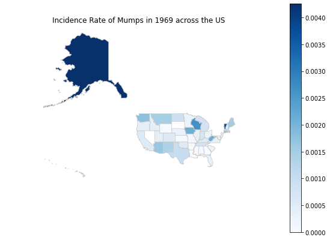

```python
sel = str(input("What year would you like to display (between 1968 and 2002? ")) #take in input
sel = int(sel) #turn into an integer for later

map_mumps_df = geopandas.GeoDataFrame(map_mumps_df, geometry='Geometry') #turning the dataframe into a geodataframe object to be used with geopandas to plot

#Here we are trying to find the min and max values to use for our scalebar
#We don't want to do this for each year because looking at the graph over time would be misleading if you kept changing the scalebars
map_mumps_df.columns.unique()
merged_cols = map_mumps_df.columns.unique()

merged_cols = merged_cols[1:-1] #only grabbing the years
vmin = map_mumps_df[merged_cols].min().min()
vmax = map_mumps_df[merged_cols].max().max()

#Plotting
fig, ax = plt.subplots(1, figsize=(10,7))
map_mumps_df.plot(column=sel, figsize=(10, 7), cmap='Blues', linewidth=0.8, ax=ax, edgecolor='0.8')
plt.xlim(-2.25e7, -0.5e7) #resetting axes
plt.ylim(0.5, 1.2e7)
ax.axis('off') #remove axis because it means nothing for us

ax.set_title(f'Incidence Rate of Mumps in {sel} across the US')

sm = plt.cm.ScalarMappable(cmap='Blues', norm=plt.Normalize(vmin=vmin, vmax=vmax)) #for color scalebar
sm._A = []
cbar = fig.colorbar(sm)
```

## New Data Set

```python
measles.head()
```

|  | disease | increase | loc | number | population | year |
| --- | --- | --- | --- | --- | --- | --- |
| 0 | MEASLES | 334.99 | ALABAMA | 8843 | 2640000 | 1928 |
| 1 | MEASLES | 200.75 | ARIZONA | 847 | 422000 | 1928 |
| 2 | MEASLES | 481.77 | ARKANSAS | 8899 | 1847000 | 1928 |
| 3 | MEASLES | 69.22 | CALIFORNIA | 3698 | 5344000 | 1928 |
| 4 | MEASLES | 206.98 | COLORADO | 2099 | 1014000 | 1928 |

Theoretically, if we understand when the largest changes in case numbers were, we might be able to make some predictions on what variables impacted that (I.E if measles sharply dropped after 1963, we could likely attribute some of that to the public availability of the measles vaccination.

```python
measles["increase"].min()
```

```
0.0
```

The flaw with this though is that increase only accounts for positive changes in case numbers, and based on the above graphs, we can see that there were years where cases were less than the year before it. In order to actually make use of this column, we will need to override it with data that we calculate from the yearly case data.

## Collaboration Plan

```python
%%shell

jupyter nbconvert --to html "/content/drive/My Drive/cmps3160/finalProject/Final_Project.ipynb"
```

[output not shown]

[output cut: 107 more lines]

[output not shown]

[output not shown]